# Glenberg & Robertson (2000) NLM Baseline Analysis

Cameron Jones

27/09/2021

# 1 Setup

```r
# Load packages
suppressMessages(library(tidyverse))
suppressMessages(library(lmerTest))
```

Summary of the data:

```r
# Load and peek data
stimuli <- read.csv("../data/clean/stimuli_analysed.csv")

# Code condition as factor
stimuli$condition <- recode(stimuli$condition,
                            afforded = "Afforded",
                            nonafforded = "Non-Afforded",
                            related = "Related")

stimuli$condition <- factor(stimuli$condition, levels=c("Related", "Afforded", "Non-Afforded"))

# Analyse e1 and e2 separately
e1 <- stimuli %>% filter(experiment == 1)
e2 <- stimuli %>% filter(experiment == 2)

summary(stimuli)
```

```
##    experiment         item           object            version
##  Min.   :1.000   Min.   : 1.000   Length:122         Length:122
##  1st Qu.:1.000   1st Qu.: 5.000   Class :character   Class :character
##  Median :2.000   Median : 9.000   Mode  :character   Mode  :character
##  Mean   :1.557   Mean   : 9.221
##  3rd Qu.:2.000   3rd Qu.:13.750
##  Max.   :2.000   Max.   :18.000
##
##         condition    setting            critical         central_word
##  Related     :18   Length:122         Length:122         Length:122
##  Afforded    :52   Class :character   Class :character   Class :character
##  Non-Afforded:52   Mode  :character   Mode  :character   Mode  :character
##
##
##
##
##  distinguishing_word    notes           key.inference      critical_masked
##  Length:122          Length:122         Length:122         Length:122
##  Class :character    Class :character   Class :character   Class :character
##  Mode  :character    Mode  :character   Mode  :character   Mode  :character
##
##
##
##
##  full_masked        bert_mask_all_mean bert_mask_one_mean bert_mask_all_sum
##  Length:122         Min.   : 2.224     Min.   : 0.3802    Min.   :  2.515
##  Class :character   1st Qu.: 9.738     1st Qu.: 3.9950    1st Qu.: 17.168
##  Mode  :character   Median :14.793     Median : 6.9522    Median : 28.901
##                     Mean   :14.647     Mean   : 7.2065    Mean   : 35.650
##                     3rd Qu.:19.721     3rd Qu.: 9.3995    3rd Qu.: 47.594
##                     Max.   :27.978     Max.   :25.7124    Max.   :118.000
##
##  bert_mask_one_sum roberta_mask_all_mean roberta_mask_one_mean
##  Min.   : 5.795    Min.   :10.45         Min.   : 1.449
##  1st Qu.:24.496    1st Qu.:17.84         1st Qu.: 8.500
##  Median :28.484    Median :20.75         Median :12.252
##  Mean   :29.874    Mean   :21.64         Mean   :13.477
##  3rd Qu.:35.182    3rd Qu.:24.35         3rd Qu.:16.334
##  Max.   :57.424    Max.   :38.79         Max.   :38.790
##
```

[output cut: 9 more lines]

```
##  Min.   :0.04028    Min.   : 81.55   Min.   : 81.29   Min.   :8.320e-08
##  1st Qu.:0.05781    1st Qu.:115.94   1st Qu.:104.55   1st Qu.:1.800e-06
##  Median :0.06814    Median :149.03   Median :129.03   Median :7.360e-06
##  Mean   :0.07157    Mean   :167.70   Mean   :145.15   Mean   :2.189e-05
##  3rd Qu.:0.08445    3rd Qu.:214.97   3rd Qu.:178.55   3rd Qu.:1.740e-05
##  Max.   :0.12017    Max.   :340.54   Max.   :300.19   Max.   :3.470e-04
##
##   dw_freq_log       dw_freq_zipf
##  Min.   :-16.302   Min.   :1.920
##  1st Qu.:-13.228   1st Qu.:3.260
##  Median :-11.819   Median :3.870
##  Mean   :-12.004   Mean   :3.787
##  3rd Qu.:-10.959   3rd Qu.:4.240
##  Max.   : -7.966   Max.   :5.540
##
```

# 2 Masked Surprisal of Distinguishing Words

The first measure is the masked probability of the distinguishing word in the critical sentence.

In item 13, for example, we find the surprisal for each distinguishing word {leaves, water, clothes} in the sentence:

> Marissa forgot to bring her pillow on her camping trip. As a substitute for her pillow, she filled up an old sweater with [MASK].

I’ve run all of the examples through BERT (large, cased) and RoBERTA (large).

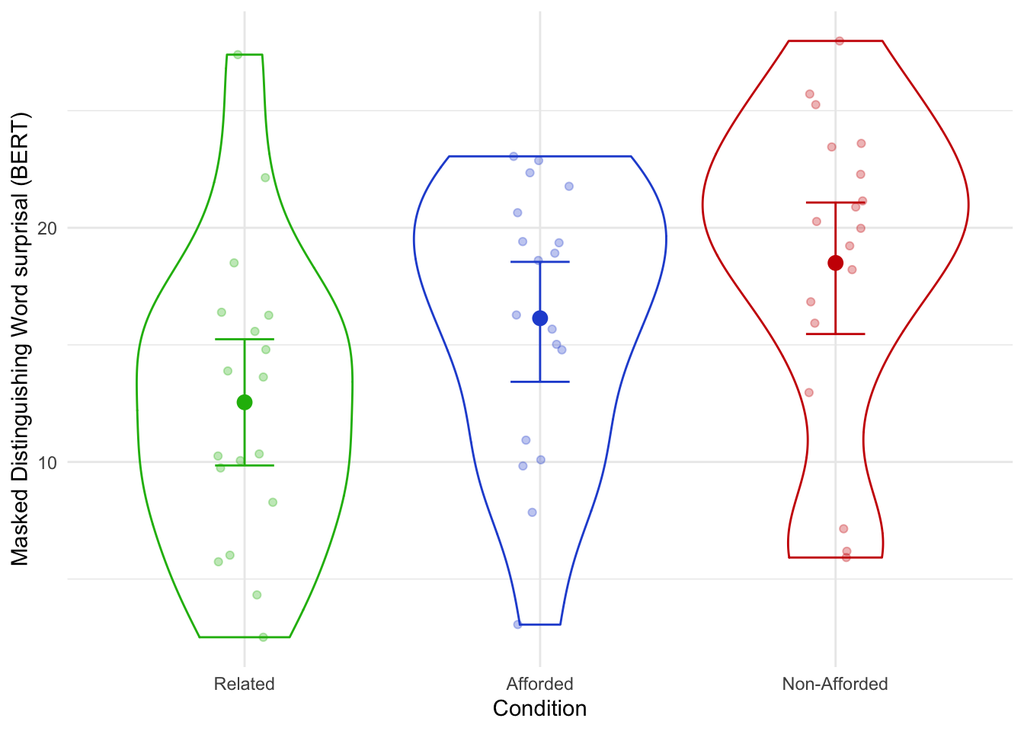

```r
e1 %>%
  ggplot(aes(x = condition, y = bert_mask_all_mean, color=condition)) +
  geom_point(position=position_jitter(width=0.1), alpha=0.3) +
  stat_summary(fun.data="mean_cl_boot", geom="point", size=3) +
  stat_summary(fun.data="mean_cl_boot", geom="errorbar", width=0.2) +
  geom_violin(alpha=0) +
  theme_minimal() +
  theme(
    legend.position = "none"
  ) +
  scale_color_manual("Condition",
     values = c("#1eb809", "#2654d4", "#cc0502")) +
  labs(
    y = "Masked Distinguishing Word surprisal (BERT)",
    x = "Condition"
  )
```

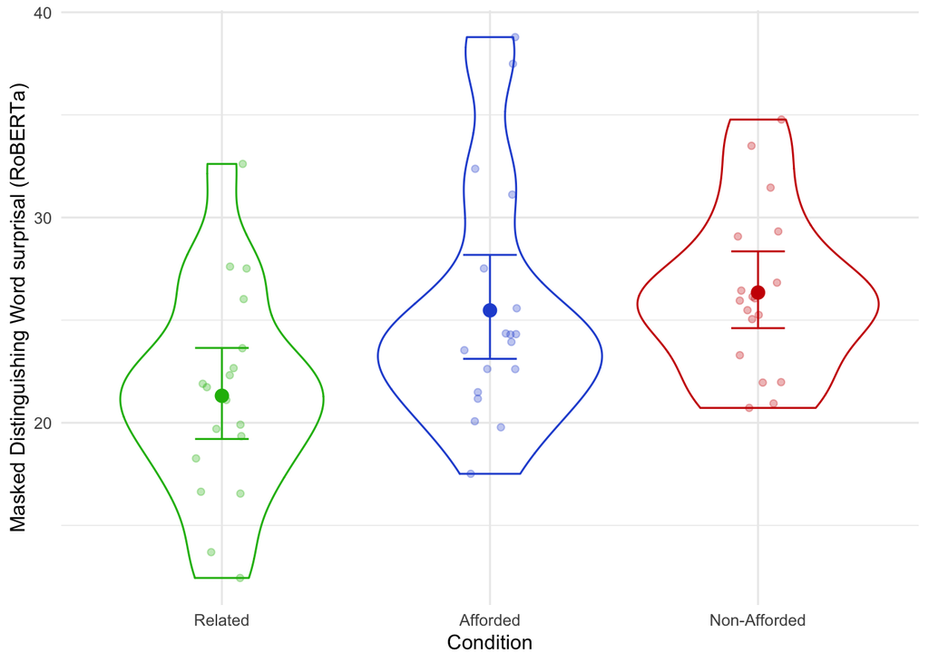

```r
e1 %>%
  ggplot(aes(x = condition, y = roberta_mask_all_mean, color=condition)) +
  geom_point(position=position_jitter(width=0.1), alpha=0.3) +
  stat_summary(fun.data="mean_cl_boot", geom="point", size=3) +
  stat_summary(fun.data="mean_cl_boot", geom="errorbar", width=0.2) +
  geom_violin(alpha=0) +
  theme_minimal() +
  theme(
    legend.position = "none"
  ) +
  scale_color_manual("Condition",
     values = c("#1eb809", "#2654d4", "#cc0502")) +
  labs(
    y = "Masked Distinguishing Word surprisal (RoBERTa)",
    x = "Condition"
  )
```

## 2.1 Models

To compare surprisal between conditions I created two different models: one to compare Afforded to Related, and one to compare Non-Afforded to Afforded.

### 2.1.1 Related vs Afforded

In both models I added a random intercept by item. I wanted to add a random slope (to control for the fact that there might variable influence of the manipulation on surprisal across items) but there are too few data points.

The model summary (using `lmerTest` to get degrees of freedom) shows positive effect which approaches significance. An LRT finds a marginally significant improvement in fit for adding condition info.

```r
# Comparison 1: Afforded to related
e1.aff.rel <- e1 %>% filter(condition %in% c("Afforded", "Related"))

m.aff.rel.bert.base <- lmer("bert_mask_all_mean ~ 1 + dw_freq_zipf +
                            (1 | item)",
                            data=e1.aff.rel,
                            REML = F)
```

```
## boundary (singular) fit: see ?isSingular
```

```r
m.aff.rel.bert.full <- lmer("bert_mask_all_mean ~ condition + dw_freq_zipf +
                            (1 | item)",
                            data=e1.aff.rel,
                            REML = F)

summary(m.aff.rel.bert.full)
```

```
## Linear mixed model fit by maximum likelihood . t-tests use Satterthwaite's
##   method [lmerModLmerTest]
## Formula:
## "bert_mask_all_mean ~ condition + dw_freq_zipf + \n                            (1 | item)"
##    Data: e1.aff.rel
##
##      AIC      BIC   logLik deviance df.resid
##    231.5    239.5   -110.8    221.5       31
##
## Scaled residuals:
##      Min       1Q   Median       3Q      Max
## -2.10124 -0.55570 -0.02367  0.58801  2.03326
##
## Random effects:
##  Groups   Name        Variance Std.Dev.
##  item     (Intercept)  2.331   1.527
##  Residual             25.316   5.032
## Number of obs: 36, groups:  item, 18
##
## Fixed effects:
##                   Estimate Std. Error     df t value Pr(>|t|)
## (Intercept)         27.677      5.012 34.794   5.522 3.36e-06 ***
## conditionAfforded    3.503      1.677 18.003   2.088  0.05125 .
## dw_freq_zipf        -3.897      1.251 34.565  -3.115  0.00368 **
## ---
## Signif. codes:  0 '***' 0.001 '**' 0.01 '*' 0.05 '.' 0.1 ' ' 1
##
## Correlation of Fixed Effects:
##             (Intr) cndtnA
## cndtnAffrdd -0.183
## dw_freq_zpf -0.969  0.017
```

```r
a.aff.rel.bert <- anova(m.aff.rel.bert.base, m.aff.rel.bert.full)
a.aff.rel.bert
```

```
## Data: e1.aff.rel
## Models:
## m.aff.rel.bert.base: "bert_mask_all_mean ~ 1 + dw_freq_zipf + \n                            (1 | item)"
## m.aff.rel.bert.full: "bert_mask_all_mean ~ condition + dw_freq_zipf + \n                            (1 | item)"
##                     npar    AIC    BIC  logLik deviance  Chisq Df Pr(>Chisq)
## m.aff.rel.bert.base    4 233.45 239.79 -112.73   225.45
## m.aff.rel.bert.full    5 231.54 239.46 -110.77   221.54 3.9157  1    0.04784 *
## ---
## Signif. codes:  0 '***' 0.001 '**' 0.01 '*' 0.05 '.' 0.1 ' ' 1
```

```r
# RoBERTa

m.aff.rel.roberta.base <- lmer("roberta_mask_all_mean ~ 1 + dw_freq_zipf +
                               (1 | item)",
                            data=e1.aff.rel,
                            REML = F)
m.aff.rel.roberta.full <- lmer("roberta_mask_all_mean ~ condition + dw_freq_zipf +
                               (1 | item)",
                            data=e1.aff.rel,
                            REML = F)

summary(m.aff.rel.roberta.full)
```

```
## Linear mixed model fit by maximum likelihood . t-tests use Satterthwaite's
##   method [lmerModLmerTest]
## Formula:
## "roberta_mask_all_mean ~ condition + dw_freq_zipf +\n                               (1 | item)"
##    Data: e1.aff.rel
##
##      AIC      BIC   logLik deviance df.resid
##    228.3    236.2   -109.1    218.3       31
##
## Scaled residuals:
##     Min      1Q  Median      3Q     Max
## -1.6827 -0.6191 -0.1519  0.5456  1.8173
##
## Random effects:
##  Groups   Name        Variance Std.Dev.
##  item     (Intercept)  8.837   2.973
##  Residual             17.818   4.221
## Number of obs: 36, groups:  item, 18
##
## Fixed effects:
##                   Estimate Std. Error     df t value Pr(>|t|)
## (Intercept)         15.908      4.613 30.794   3.449  0.00165 **
## conditionAfforded    4.193      1.407 16.688   2.979  0.00855 **
## dw_freq_zipf         1.393      1.146 29.518   1.215  0.23385
## ---
## Signif. codes:  0 '***' 0.001 '**' 0.01 '*' 0.05 '.' 0.1 ' ' 1
##
## Correlation of Fixed Effects:
##             (Intr) cndtnA
## cndtnAffrdd -0.170
## dw_freq_zpf -0.965  0.018
```

```r
a.aff.rel.roberta <- anova(m.aff.rel.roberta.base, m.aff.rel.roberta.full)
a.aff.rel.roberta
```

```
## Data: e1.aff.rel
## Models:
## m.aff.rel.roberta.base: "roberta_mask_all_mean ~ 1 + dw_freq_zipf + \n                               (1 | item)"
## m.aff.rel.roberta.full: "roberta_mask_all_mean ~ condition + dw_freq_zipf +\n                               (1 | item)"
##                        npar    AIC    BIC  logLik deviance  Chisq Df Pr(>Chisq)
## m.aff.rel.roberta.base    4 233.40 239.73 -112.70   225.40
## m.aff.rel.roberta.full    5 228.26 236.17 -109.13   218.26 7.1417  1   0.007531
##
## m.aff.rel.roberta.base
## m.aff.rel.roberta.full **
## ---
## Signif. codes:  0 '***' 0.001 '**' 0.01 '*' 0.05 '.' 0.1 ' ' 1
```

### 2.1.2 Afforded vs Non-Afforded

The lmerTest summary shows no significant effect on BERT surprisal for the Afforded/Non-Afforded distinction. An LRT is also non-significant.

```r
# Comparison 2: Afforded to Non-Afforded
e1.aff.naff <- e1 %>% filter(condition %in% c("Afforded", "Non-Afforded"))

m.aff.naff.bert.base <- lmer("bert_mask_all_mean ~ 1 + dw_freq_zipf +
                             (1 | item)",
                            data=e1.aff.naff,
                            REML = F)
```

```
## boundary (singular) fit: see ?isSingular
```

```r
m.aff.naff.bert.full <- lmer("bert_mask_all_mean ~ condition + dw_freq_zipf +
                             (1 | item)",
                            data=e1.aff.naff,
                            REML = F)
```

```
## boundary (singular) fit: see ?isSingular
```

```r
summary(m.aff.naff.bert.full)
```

```
## Linear mixed model fit by maximum likelihood . t-tests use Satterthwaite's
##   method [lmerModLmerTest]
## Formula:
## "bert_mask_all_mean ~ condition + dw_freq_zipf + \n                             (1 | item)"
##    Data: e1.aff.naff
##
##      AIC      BIC   logLik deviance df.resid
##    218.7    226.6   -104.4    208.7       31
##
## Scaled residuals:
##      Min       1Q   Median       3Q      Max
## -2.12511 -0.60549 -0.08522  0.75679  1.85575
##
## Random effects:
##  Groups   Name        Variance Std.Dev.
##  item     (Intercept)  0.00    0.000
##  Residual             19.29    4.392
## Number of obs: 36, groups:  item, 18
##
## Fixed effects:
##                       Estimate Std. Error      df t value Pr(>|t|)
## (Intercept)            35.9421     3.6424 36.0000   9.868 8.86e-12 ***
## conditionNon-Afforded   2.0501     1.4652 36.0000   1.399     0.17
## dw_freq_zipf           -5.1314     0.9048 36.0000  -5.671 1.91e-06 ***
## ---
## Signif. codes:  0 '***' 0.001 '**' 0.01 '*' 0.05 '.' 0.1 ' ' 1
##
## Correlation of Fixed Effects:
##             (Intr) cndN-A
## cndtnNn-Aff -0.237
## dw_freq_zpf -0.959  0.037
## optimizer (nloptwrap) convergence code: 0 (OK)
## boundary (singular) fit: see ?isSingular
```

```r
a.aff.naff.bert <- anova(m.aff.naff.bert.base, m.aff.naff.bert.full)
a.aff.naff.bert
```

```
## Data: e1.aff.naff
## Models:
## m.aff.naff.bert.base: "bert_mask_all_mean ~ 1 + dw_freq_zipf + \n                             (1 | item)"
## m.aff.naff.bert.full: "bert_mask_all_mean ~ condition + dw_freq_zipf + \n                             (1 | item)"
##                      npar    AIC    BIC  logLik deviance  Chisq Df Pr(>Chisq)
## m.aff.naff.bert.base    4 218.62 224.96 -105.31   210.62
## m.aff.naff.bert.full    5 218.72 226.63 -104.36   208.72 1.9064  1     0.1674
```

Nor for RoBERTa

```r
# RoBERTa

m.aff.naff.roberta.base <- lmer("roberta_mask_all_mean ~ 1 + dw_freq_zipf + (1 | item)",
                            data=e1.aff.naff,
                            REML = F)
```

```
## boundary (singular) fit: see ?isSingular
```

```r
m.aff.naff.roberta.full <- lmer("roberta_mask_all_mean ~ condition + dw_freq_zipf +
                                (1 | item)",
                            data=e1.aff.naff,
                            REML = F)

summary(m.aff.naff.roberta.full)
```

```
## Linear mixed model fit by maximum likelihood . t-tests use Satterthwaite's
##   method [lmerModLmerTest]
## Formula:
## "roberta_mask_all_mean ~ condition + dw_freq_zipf +\n                                (1 | item)"
##    Data: e1.aff.naff
##
##      AIC      BIC   logLik deviance df.resid
##    218.9    226.8   -104.4    208.9       31
##
## Scaled residuals:
##     Min      1Q  Median      3Q     Max
## -1.7414 -0.7978 -0.1388  0.8024  2.4299
##
## Random effects:
##  Groups   Name        Variance Std.Dev.
##  item     (Intercept)  0.1583  0.3978
##  Residual             19.2303  4.3852
## Number of obs: 36, groups:  item, 18
##
## Fixed effects:
##                       Estimate Std. Error      df t value Pr(>|t|)
## (Intercept)            15.1694     3.6562 31.1356   4.149  0.00024 ***
## conditionNon-Afforded   1.0312     1.4628 14.5752   0.705  0.49194
## dw_freq_zipf            2.6707     0.9084 30.4036   2.940  0.00622 **
## ---
## Signif. codes:  0 '***' 0.001 '**' 0.01 '*' 0.05 '.' 0.1 ' ' 1
##
## Correlation of Fixed Effects:
##             (Intr) cndN-A
## cndtnNn-Aff -0.236
## dw_freq_zpf -0.959  0.038
```

```r
a.aff.naff.roberta <- anova(m.aff.naff.roberta.base, m.aff.naff.roberta.full)
a.aff.naff.roberta
```

```
## Data: e1.aff.naff
## Models:
## m.aff.naff.roberta.base: "roberta_mask_all_mean ~ 1 + dw_freq_zipf + (1 | item)"
## m.aff.naff.roberta.full: "roberta_mask_all_mean ~ condition + dw_freq_zipf +\n                                (1 | item)"
##                         npar    AIC    BIC  logLik deviance  Chisq Df
## m.aff.naff.roberta.base    4 217.38 223.72 -104.69   209.38
## m.aff.naff.roberta.full    5 218.89 226.81 -104.45   208.89 0.4914  1
##                         Pr(>Chisq)
## m.aff.naff.roberta.base
## m.aff.naff.roberta.full     0.4833
```

Overall the results suggest that models are more sensitive to the Related/Afforded distinction (lower surprisal for Related); but not as sensitive to the affordances of non-related concepts.

# 3 Next Sentence Prediction

In order to elicit probabilities from these activation values, I just used softmax (which I don’t think works very well with so few values, often the values are e.g. (6, -6)). In general the probabilities are all very high and don’t show much variation.

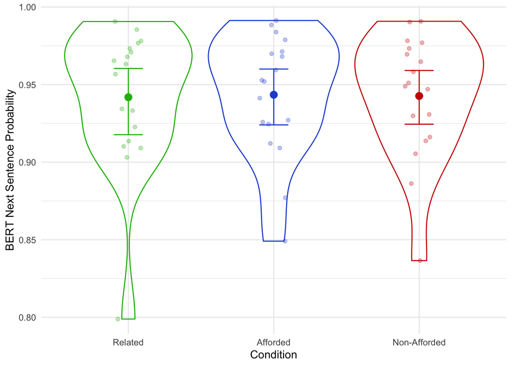

```r
e1 %>%
  ggplot(aes(x = condition, y = bert_nsp, color=condition)) +
  geom_point(position=position_jitter(width=0.1), alpha=0.3) +
  stat_summary(fun.data="mean_cl_boot", geom="point", size=3) +
  stat_summary(fun.data="mean_cl_boot", geom="errorbar", width=0.2) +
  geom_violin(alpha=0) +
  theme_minimal() +
  theme(
    legend.position = "none"
  ) +
  scale_color_manual("Condition",
     values = c("#1eb809", "#2654d4", "#cc0502")) +
  labs(
    y = "BERT Next Sentence Probability",
    x = "Condition"
  )
```

Models show no difference of condition for either comparison

```r
m.aff.rel.bert.nsp.base <- lmer("bert_nsp ~ 1 + dw_freq_zipf + (1 | item)",
                            data=e1.aff.rel,
                            REML = F)
m.aff.rel.bert.nsp.full <- lmer("bert_nsp ~ condition + dw_freq_zipf + (1 | item)",
                            data=e1.aff.rel,
                            REML = F)

summary(m.aff.rel.bert.nsp.full)
```

```
## Linear mixed model fit by maximum likelihood . t-tests use Satterthwaite's
##   method [lmerModLmerTest]
## Formula: "bert_nsp ~ condition + dw_freq_zipf + (1 | item)"
##    Data: e1.aff.rel
##
##      AIC      BIC   logLik deviance df.resid
##   -142.6   -134.7     76.3   -152.6       31
##
## Scaled residuals:
##      Min       1Q   Median       3Q      Max
## -2.19633 -0.31132  0.02972  0.35231  1.71529
##
## Random effects:
##  Groups   Name        Variance  Std.Dev.
##  item     (Intercept) 0.0015039 0.03878
##  Residual             0.0002209 0.01486
## Number of obs: 36, groups:  item, 18
##
## Fixed effects:
##                    Estimate Std. Error        df t value Pr(>|t|)
## (Intercept)        0.929513   0.020501 28.916870  45.340   <2e-16 ***
## conditionAfforded  0.001661   0.004955 17.992802   0.335    0.741
## dw_freq_zipf       0.003184   0.004641 19.915414   0.686    0.501
## ---
## Signif. codes:  0 '***' 0.001 '**' 0.01 '*' 0.05 '.' 0.1 ' ' 1
##
## Correlation of Fixed Effects:
##             (Intr) cndtnA
## cndtnAffrdd -0.139
## dw_freq_zpf -0.879  0.021
```

```r
a.aff.rel.bert.nsp <- anova(m.aff.rel.bert.nsp.base, m.aff.rel.bert.nsp.full)
a.aff.rel.bert.nsp
```

```
## Data: e1.aff.rel
## Models:
## m.aff.rel.bert.nsp.base: "bert_nsp ~ 1 + dw_freq_zipf + (1 | item)"
## m.aff.rel.bert.nsp.full: "bert_nsp ~ condition + dw_freq_zipf + (1 | item)"
##                         npar     AIC     BIC logLik deviance  Chisq Df
## m.aff.rel.bert.nsp.base    4 -144.49 -138.16 76.245  -152.49
## m.aff.rel.bert.nsp.full    5 -142.60 -134.69 76.301  -152.60 0.1121  1
##                         Pr(>Chisq)
## m.aff.rel.bert.nsp.base
## m.aff.rel.bert.nsp.full     0.7378
```

```r
m.aff.naff.bert.nsp.base <- lmer("bert_nsp ~ 1 + dw_freq_zipf + (1 | item)",
                            data=e1.aff.naff,
                            REML = F)
m.aff.naff.bert.nsp.full <- lmer("bert_nsp ~ condition + dw_freq_zipf + (1 | item)",
                            data=e1.aff.naff,
                            REML = F)

summary(m.aff.naff.bert.nsp.full)
```

```
## Linear mixed model fit by maximum likelihood . t-tests use Satterthwaite's
##   method [lmerModLmerTest]
## Formula: "bert_nsp ~ condition + dw_freq_zipf + (1 | item)"
##    Data: e1.aff.naff
##
##      AIC      BIC   logLik deviance df.resid
##   -169.2   -161.3     89.6   -179.2       31
##
## Scaled residuals:
##      Min       1Q   Median       3Q      Max
## -2.07975 -0.29581  0.05242  0.35125  1.81416
##
## Random effects:
##  Groups   Name        Variance  Std.Dev.
##  item     (Intercept) 1.428e-03 0.037783
##  Residual             5.583e-05 0.007472
## Number of obs: 36, groups:  item, 18
##
## Fixed effects:
##                         Estimate Std. Error         df t value Pr(>|t|)
## (Intercept)            0.9430347  0.0137270 35.6573456  68.699   <2e-16 ***
## conditionNon-Afforded -0.0007842  0.0024960 17.9391975  -0.314    0.757
## dw_freq_zipf           0.0001111  0.0026679 19.3997025   0.042    0.967
## ---
## Signif. codes:  0 '***' 0.001 '**' 0.01 '*' 0.05 '.' 0.1 ' ' 1
##
## Correlation of Fixed Effects:
##             (Intr) cndN-A
## cndtnNn-Aff -0.139
## dw_freq_zpf -0.750  0.065
```

```r
a.aff.naff.bert.nsp <- anova(m.aff.naff.bert.nsp.base, m.aff.naff.bert.nsp.full)
a.aff.naff.bert.nsp
```

```
## Data: e1.aff.naff
## Models:
## m.aff.naff.bert.nsp.base: "bert_nsp ~ 1 + dw_freq_zipf + (1 | item)"
## m.aff.naff.bert.nsp.full: "bert_nsp ~ condition + dw_freq_zipf + (1 | item)"
##                          npar     AIC     BIC logLik deviance  Chisq Df
## m.aff.naff.bert.nsp.base    4 -171.12 -164.79 89.561  -179.12
## m.aff.naff.bert.nsp.full    5 -169.22 -161.30 89.610  -179.22 0.0985  1
##                          Pr(>Chisq)
## m.aff.naff.bert.nsp.base
## m.aff.naff.bert.nsp.full     0.7537
```

Overall I think this metric just isn’t sensitive enough to get at the relatively small manipulation we are interested in. The lack of effect for Related-Afforded means it doesn’t seem appropriate to use this metric to test for an effect of Afforded/Non-Afforded.

# 4 Embeddings

The last method, closest to the controls in the original paper, is to find the distance between the embeddings of:

1. The central and distinguishing words in a sentence
2. The setting and critical sentences

The stimuli did not contain information about the central concept, we used the example in the paper to re-create our best guess for what the central concept is.

For example, in Item 13, we use “pillow”, and find the cosine between the contextualised embedding for “pillow” and “leaves”.

> Marissa forgot to bring her pillow on her camping trip. As a substitute for her pillow, she filled up an old sweater with leaves.

Where the central or distinguishing phrase is multi-token, we take the mean of the embedding for all tokens. To find the embedding for the sentences, we take the mean of all tokens in the sentence (following this [tutorial](https://mccormickml.com/2019/05/14/BERT-word-embeddings-tutorial/#3-extracting-embeddings), thanks Sean for sending!). We could also try using the [CLS] token).

For all embeddings, I have used the second-to-last layer of BERT. It seems to perform [comparably](https://jalammar.github.io/illustrated-bert/#bert-for-feature-extraction) with more complex strategies.

In all cases, I’ve taken the cosine distance between the two resulting vectors.

## 4.1 Central-Distinguishing

For the central-distinguishing embedding, we see a similar pattern to the mask results above: the distance for related continuations is lower than for Afforded and Non-Afforded continuations, which are comparable.

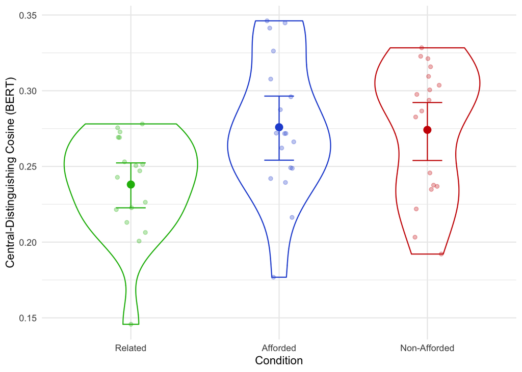

```r
e1 %>%
  ggplot(aes(x = condition, y = cd_cosine_bert_ln2, color=condition)) +
  geom_point(position=position_jitter(width=0.1), alpha=0.3) +
  stat_summary(fun.data="mean_cl_boot", geom="point", size=3) +
  stat_summary(fun.data="mean_cl_boot", geom="errorbar", width=0.2) +
  geom_violin(alpha=0) +
  theme_minimal() +
  theme(
    legend.position = "none"
  ) +
  scale_color_manual("Condition",
     values = c("#1eb809", "#2654d4", "#cc0502")) +
  labs(
    y = "Central-Distinguishing Cosine (BERT)",
    x = "Condition"
  )
```

### 4.1.1 Related vs Afforded

The model shows a significant positive effect of Afforded vs Related on cosine distance.

```r
# Comparison 1: Afforded to related
m.aff.rel.cd_cosine_bert_ln2.base <- lmer("cd_cosine_bert_ln2 ~ 1 + dw_freq_zipf +
                                          (1 | item)",
                            data=e1.aff.rel,
                            REML = F)
```

```
## boundary (singular) fit: see ?isSingular
```

```r
m.aff.rel.cd_cosine_bert_ln2.full <- lmer("cd_cosine_bert_ln2 ~ condition +
                                          dw_freq_zipf + (1 | item)",
                            data=e1.aff.rel,
                            REML = F)

summary(m.aff.rel.cd_cosine_bert_ln2.full)
```

```
## Linear mixed model fit by maximum likelihood . t-tests use Satterthwaite's
##   method [lmerModLmerTest]
## Formula:
## "cd_cosine_bert_ln2 ~ condition +\n                                          dw_freq_zipf + (1 | item)"
##    Data: e1.aff.rel
##
##      AIC      BIC   logLik deviance df.resid
##   -122.9   -115.0     66.5   -132.9       31
##
## Scaled residuals:
##     Min      1Q  Median      3Q     Max
## -2.3366 -0.5722 -0.0975  0.7660  1.9945
##
## Random effects:
##  Groups   Name        Variance  Std.Dev.
##  item     (Intercept) 0.0001603 0.01266
##  Residual             0.0013063 0.03614
## Number of obs: 36, groups:  item, 18
##
## Fixed effects:
##                    Estimate Std. Error        df t value Pr(>|t|)
## (Intercept)        0.202158   0.036371 34.397455   5.558 3.12e-06 ***
## conditionAfforded  0.038038   0.012049 17.258134   3.157  0.00568 **
## dw_freq_zipf       0.009247   0.009077 34.077905   1.019  0.31549
## ---
## Signif. codes:  0 '***' 0.001 '**' 0.01 '*' 0.05 '.' 0.1 ' ' 1
##
## Correlation of Fixed Effects:
##             (Intr) cndtnA
## cndtnAffrdd -0.182
## dw_freq_zpf -0.969  0.017
```

```r
a.aff.rel.cd_cosine_bert_ln2 <- anova(m.aff.rel.cd_cosine_bert_ln2.base, m.aff.rel.cd_cosine_bert_ln2.full)

a.aff.rel.cd_cosine_bert_ln2
```

```
## Data: e1.aff.rel
## Models:
## m.aff.rel.cd_cosine_bert_ln2.base: "cd_cosine_bert_ln2 ~ 1 + dw_freq_zipf + \n                                          (1 | item)"
## m.aff.rel.cd_cosine_bert_ln2.full: "cd_cosine_bert_ln2 ~ condition +\n                                          dw_freq_zipf + (1 | item)"
##                                   npar     AIC     BIC logLik deviance  Chisq
## m.aff.rel.cd_cosine_bert_ln2.base    4 -116.80 -110.46 62.399  -124.80
## m.aff.rel.cd_cosine_bert_ln2.full    5 -122.94 -115.03 66.472  -132.94 8.1466
##                                   Df Pr(>Chisq)
## m.aff.rel.cd_cosine_bert_ln2.base
## m.aff.rel.cd_cosine_bert_ln2.full  1   0.004314 **
## ---
## Signif. codes:  0 '***' 0.001 '**' 0.01 '*' 0.05 '.' 0.1 ' ' 1
```

### 4.1.2 Afforded vs Non-Afforded

However we see no significant effect of afforded vs non-afforded

```r
# Comparison 1: Afforded to related
m.aff.naff.cd_cosine_bert_ln2.base <- lmer("cd_cosine_bert_ln2 ~ dw_freq_zipf +
                                           (1 | item)",
                            data=e1.aff.naff,
                            REML = F)
m.aff.naff.cd_cosine_bert_ln2.full <- lmer("cd_cosine_bert_ln2 ~ condition +
                                           dw_freq_zipf + (1 | item)",
                            data=e1.aff.naff,
                            REML = F)

summary(m.aff.naff.cd_cosine_bert_ln2.full)
```

```
## Linear mixed model fit by maximum likelihood . t-tests use Satterthwaite's
##   method [lmerModLmerTest]
## Formula:
## "cd_cosine_bert_ln2 ~ condition +\n                                           dw_freq_zipf + (1 | item)"
##    Data: e1.aff.naff
##
##      AIC      BIC   logLik deviance df.resid
##   -125.1   -117.2     67.6   -135.1       31
##
## Scaled residuals:
##      Min       1Q   Median       3Q      Max
## -1.54452 -0.31856  0.06577  0.55910  1.43158
##
## Random effects:
##  Groups   Name        Variance  Std.Dev.
##  item     (Intercept) 0.0013703 0.03702
##  Residual             0.0005687 0.02385
## Number of obs: 36, groups:  item, 18
##
## Fixed effects:
##                        Estimate Std. Error        df t value Pr(>|t|)
## (Intercept)            0.287809   0.030509 32.110924   9.434 8.94e-11 ***
## conditionNon-Afforded -0.001924   0.007962 17.030395  -0.242    0.812
## dw_freq_zipf          -0.003089   0.007433 28.998952  -0.416    0.681
## ---
## Signif. codes:  0 '***' 0.001 '**' 0.01 '*' 0.05 '.' 0.1 ' ' 1
##
## Correlation of Fixed Effects:
##             (Intr) cndN-A
## cndtnNn-Aff -0.183
## dw_freq_zpf -0.940  0.057
```

```r
a.aff.naff.cd_cosine_bert_ln2 <- anova(m.aff.naff.cd_cosine_bert_ln2.base, m.aff.naff.cd_cosine_bert_ln2.full)

a.aff.naff.cd_cosine_bert_ln2
```

```
## Data: e1.aff.naff
## Models:
## m.aff.naff.cd_cosine_bert_ln2.base: "cd_cosine_bert_ln2 ~ dw_freq_zipf + \n                                           (1 | item)"
## m.aff.naff.cd_cosine_bert_ln2.full: "cd_cosine_bert_ln2 ~ condition +\n                                           dw_freq_zipf + (1 | item)"
##                                    npar     AIC     BIC logLik deviance  Chisq
## m.aff.naff.cd_cosine_bert_ln2.base    4 -127.08 -120.74 67.538  -135.08
## m.aff.naff.cd_cosine_bert_ln2.full    5 -125.14 -117.22 67.568  -135.13 0.0582
##                                    Df Pr(>Chisq)
## m.aff.naff.cd_cosine_bert_ln2.base
## m.aff.naff.cd_cosine_bert_ln2.full  1     0.8093
```

## 4.2 Setting-Critical

The setting-critical embedding cosines show a larger gap for Afforded/Non-Afforded than for Afforded/Related

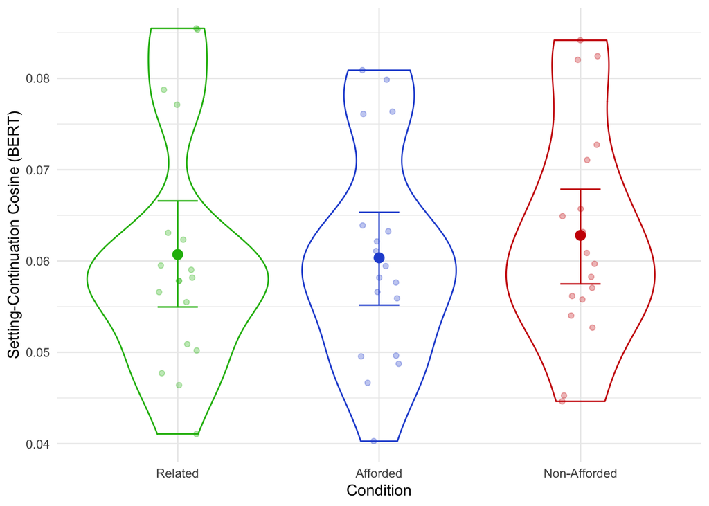

```r
e1 %>%
  ggplot(aes(x = condition, y = sc_cosine_bert_ln2, color=condition)) +
  geom_point(position=position_jitter(width=0.1), alpha=0.3) +
  stat_summary(fun.data="mean_cl_boot", geom="point", size=3) +
  stat_summary(fun.data="mean_cl_boot", geom="errorbar", width=0.2) +
  geom_violin(alpha=0) +
  theme_minimal() +
  theme(
    legend.position = "none"
  ) +
  scale_color_manual("Condition",
     values = c("#1eb809", "#2654d4", "#cc0502")) +
  labs(
    y = "Setting-Continuation Cosine (BERT)",
    x = "Condition"
  )
```

### 4.2.1 Related vs Afforded

There is no effect of related/afforded on sc_cosine.

```r
# Comparison 1: Afforded to related
m.aff.rel.sc_cosine_bert_ln2.base <- lmer("sc_cosine_bert_ln2 ~ 1 + dw_freq_zipf +
                                          (1 | item)",
                            data=e1.aff.rel,
                            REML = F)
m.aff.rel.sc_cosine_bert_ln2.full <- lmer("sc_cosine_bert_ln2 ~ condition +
                                          dw_freq_zipf + (1 | item)",
                            data=e1.aff.rel,
                            REML = F)

summary(m.aff.rel.sc_cosine_bert_ln2.full)
```

```
## Linear mixed model fit by maximum likelihood . t-tests use Satterthwaite's
##   method [lmerModLmerTest]
## Formula:
## "sc_cosine_bert_ln2 ~ condition +\n                                          dw_freq_zipf + (1 | item)"
##    Data: e1.aff.rel
##
##      AIC      BIC   logLik deviance df.resid
##   -240.8   -232.9    125.4   -250.8       31
##
## Scaled residuals:
##      Min       1Q   Median       3Q      Max
## -1.62958 -0.37951  0.04751  0.38109  1.58241
##
## Random effects:
##  Groups   Name        Variance  Std.Dev.
##  item     (Intercept) 1.349e-04 0.011613
##  Residual             1.086e-05 0.003296
## Number of obs: 36, groups:  item, 18
##
## Fixed effects:
##                     Estimate Std. Error         df t value Pr(>|t|)
## (Intercept)        0.0578376  0.0049408 32.5991117  11.706 3.24e-13 ***
## conditionAfforded -0.0003485  0.0010987 17.9492171  -0.317    0.755
## dw_freq_zipf       0.0007399  0.0010406 19.0392322   0.711    0.486
## ---
## Signif. codes:  0 '***' 0.001 '**' 0.01 '*' 0.05 '.' 0.1 ' ' 1
##
## Correlation of Fixed Effects:
##             (Intr) cndtnA
## cndtnAffrdd -0.128
## dw_freq_zpf -0.818  0.021
```

```r
a.aff.rel.sc_cosine_bert_ln2 <- anova(m.aff.rel.sc_cosine_bert_ln2.base, m.aff.rel.sc_cosine_bert_ln2.full)

a.aff.rel.sc_cosine_bert_ln2
```

```
## Data: e1.aff.rel
## Models:
## m.aff.rel.sc_cosine_bert_ln2.base: "sc_cosine_bert_ln2 ~ 1 + dw_freq_zipf + \n                                          (1 | item)"
## m.aff.rel.sc_cosine_bert_ln2.full: "sc_cosine_bert_ln2 ~ condition +\n                                          dw_freq_zipf + (1 | item)"
##                                   npar    AIC     BIC logLik deviance  Chisq Df
## m.aff.rel.sc_cosine_bert_ln2.base    4 -242.7 -236.36 125.35   -250.7
## m.aff.rel.sc_cosine_bert_ln2.full    5 -240.8 -232.88 125.40   -250.8 0.1003  1
##                                   Pr(>Chisq)
## m.aff.rel.sc_cosine_bert_ln2.base
## m.aff.rel.sc_cosine_bert_ln2.full     0.7514
```

### 4.2.2 Afforded vs Non-Afforded

However the Afforded/Non-Afforded effect approaches significance.

```r
# Comparison 1: Afforded to related
m.aff.naff.sc_cosine_bert_ln2.base <- lmer("sc_cosine_bert_ln2 ~ dw_freq_zipf +
                                           (1 | item)",
                            data=e1.aff.naff,
                            REML = F)
m.aff.naff.sc_cosine_bert_ln2.full <- lmer("sc_cosine_bert_ln2 ~ condition +
                                           dw_freq_zipf + (1 | item)",
                            data=e1.aff.naff,
                            REML = F)

summary(m.aff.naff.sc_cosine_bert_ln2.full)
```

```
## Linear mixed model fit by maximum likelihood . t-tests use Satterthwaite's
##   method [lmerModLmerTest]
## Formula:
## "sc_cosine_bert_ln2 ~ condition +\n                                           dw_freq_zipf + (1 | item)"
##    Data: e1.aff.naff
##
##      AIC      BIC   logLik deviance df.resid
##   -235.0   -227.1    122.5   -245.0       31
##
## Scaled residuals:
##      Min       1Q   Median       3Q      Max
## -1.48363 -0.35337  0.01362  0.37437  1.71703
##
## Random effects:
##  Groups   Name        Variance  Std.Dev.
##  item     (Intercept) 1.127e-04 0.010616
##  Residual             1.729e-05 0.004158
## Number of obs: 36, groups:  item, 18
##
## Fixed effects:
##                        Estimate Std. Error        df t value Pr(>|t|)
## (Intercept)            0.057261   0.006074 30.536869   9.427 1.49e-10 ***
## conditionNon-Afforded  0.002515   0.001389 18.016586   1.812   0.0868 .
## dw_freq_zipf           0.000799   0.001411 23.330176   0.566   0.5767
## ---
## Signif. codes:  0 '***' 0.001 '**' 0.01 '*' 0.05 '.' 0.1 ' ' 1
##
## Correlation of Fixed Effects:
##             (Intr) cndN-A
## cndtnNn-Aff -0.169
## dw_freq_zpf -0.897  0.062
```

```r
a.aff.naff.sc_cosine_bert_ln2 <- anova(m.aff.naff.sc_cosine_bert_ln2.base, m.aff.naff.sc_cosine_bert_ln2.full)

a.aff.naff.sc_cosine_bert_ln2
```

```
## Data: e1.aff.naff
## Models:
## m.aff.naff.sc_cosine_bert_ln2.base: "sc_cosine_bert_ln2 ~ dw_freq_zipf + \n                                           (1 | item)"
## m.aff.naff.sc_cosine_bert_ln2.full: "sc_cosine_bert_ln2 ~ condition +\n                                           dw_freq_zipf + (1 | item)"
##                                    npar     AIC     BIC logLik deviance  Chisq
## m.aff.naff.sc_cosine_bert_ln2.base    4 -234.03 -227.69 121.01  -242.03
## m.aff.naff.sc_cosine_bert_ln2.full    5 -235.04 -227.13 122.52  -245.04 3.0157
##                                    Df Pr(>Chisq)
## m.aff.naff.sc_cosine_bert_ln2.base
## m.aff.naff.sc_cosine_bert_ln2.full  1    0.08246 .
## ---
## Signif. codes:  0 '***' 0.001 '**' 0.01 '*' 0.05 '.' 0.1 ' ' 1
```

# 5 GPT-3

For GPT-3 I used the total surprisal of the setting and critical sentence together.

There is not much obvious variation in the visualisation, but this measure contains a lot of noise (surprisal of words before the distinguishing word) that should be dealt with by item intercepts.

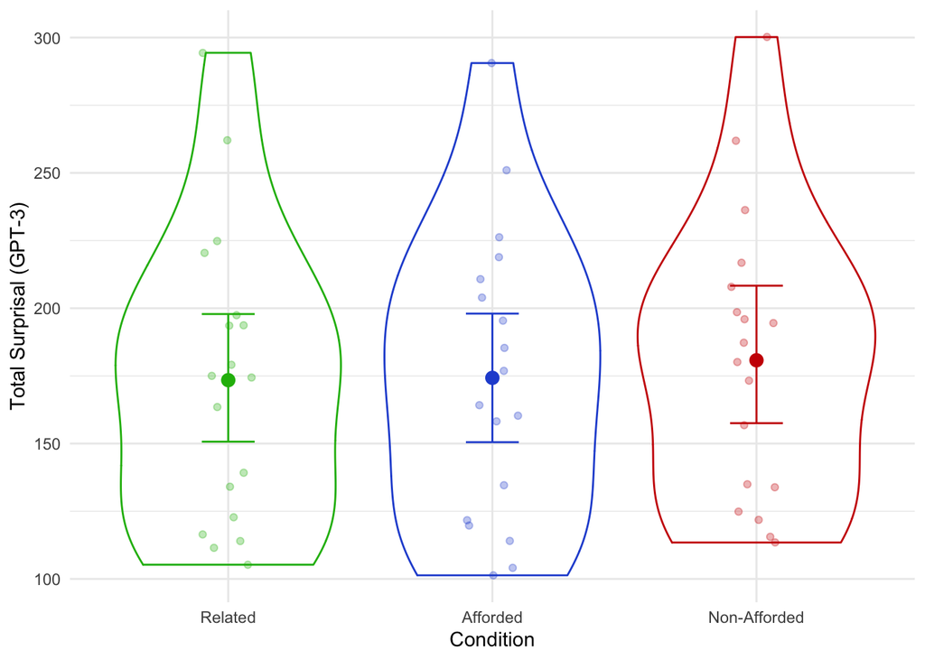

```r
e1 %>%
  ggplot(aes(x = condition, y = gpt3_davinci_spl, color=condition)) +
  geom_point(position=position_jitter(width=0.1), alpha=0.3) +
  stat_summary(fun.data="mean_cl_boot", geom="point", size=3) +
  stat_summary(fun.data="mean_cl_boot", geom="errorbar", width=0.2) +
  geom_violin(alpha=0) +
  theme_minimal() +
  theme(
    legend.position = "none"
  ) +
  scale_color_manual("Condition",
     values = c("#1eb809", "#2654d4", "#cc0502")) +
  labs(
    y = "Total Surprisal (GPT-3)",
    x = "Condition"
  )
```

## 5.1 Related vs Afforded

GPT-3 shows no effect of Afforded vs Related on total surprisal.

```r
# Comparison 1: Afforded to related
m.aff.rel.gpt3_davinci_spl.base <- lmer("gpt3_davinci_spl ~ 1 + dw_freq_zipf +
                                          (1 | item)",
                            data=e1.aff.rel,
                            REML = F)
m.aff.rel.gpt3_davinci_spl.full <- lmer("gpt3_davinci_spl ~ condition +
                                          dw_freq_zipf + (1 | item)",
                            data=e1.aff.rel,
                            REML = F)

summary(m.aff.rel.gpt3_davinci_spl.full)
```

```
## Linear mixed model fit by maximum likelihood . t-tests use Satterthwaite's
##   method [lmerModLmerTest]
## Formula:
## "gpt3_davinci_spl ~ condition +\n                                          dw_freq_zipf + (1 | item)"
##    Data: e1.aff.rel
##
##      AIC      BIC   logLik deviance df.resid
##    331.9    339.8   -160.9    321.9       31
##
## Scaled residuals:
##      Min       1Q   Median       3Q      Max
## -1.72087 -0.38506  0.00759  0.44307  1.66506
##
## Random effects:
##  Groups   Name        Variance Std.Dev.
##  item     (Intercept) 2713.37  52.090
##  Residual               36.57   6.047
## Number of obs: 36, groups:  item, 18
##
## Fixed effects:
##                   Estimate Std. Error       df t value Pr(>|t|)
## (Intercept)       188.6183    14.4597  29.8338  13.044 7.38e-14 ***
## conditionAfforded   0.7626     2.0162  17.9941   0.378   0.7097
## dw_freq_zipf       -3.9131     1.9331  18.1827  -2.024   0.0579 .
## ---
## Signif. codes:  0 '***' 0.001 '**' 0.01 '*' 0.05 '.' 0.1 ' ' 1
##
## Correlation of Fixed Effects:
##             (Intr) cndtnA
## cndtnAffrdd -0.081
## dw_freq_zpf -0.519  0.021
```

```r
a.aff.rel.gpt3_davinci_spl <- anova(m.aff.rel.gpt3_davinci_spl.base, m.aff.rel.gpt3_davinci_spl.full)

a.aff.rel.gpt3_davinci_spl
```

```
## Data: e1.aff.rel
## Models:
## m.aff.rel.gpt3_davinci_spl.base: "gpt3_davinci_spl ~ 1 + dw_freq_zipf + \n                                          (1 | item)"
## m.aff.rel.gpt3_davinci_spl.full: "gpt3_davinci_spl ~ condition +\n                                          dw_freq_zipf + (1 | item)"
##                                 npar    AIC    BIC  logLik deviance  Chisq Df
## m.aff.rel.gpt3_davinci_spl.base    4 330.00 336.33 -161.00   322.00
## m.aff.rel.gpt3_davinci_spl.full    5 331.85 339.77 -160.93   321.85 0.1425  1
##                                 Pr(>Chisq)
## m.aff.rel.gpt3_davinci_spl.base
## m.aff.rel.gpt3_davinci_spl.full     0.7058
```

## 5.2 Afforded vs Non-Afforded

However in contrast to the BERT-family results, we *do* see a difference of Afforded vs Non-Afforded.

```r
# Comparison 1: Afforded to related
m.aff.naff.gpt3_davinci_spl.base <- lmer("gpt3_davinci_spl ~ dw_freq_zipf +
                                           (1 | item)",
                            data=e1.aff.naff,
                            REML = F)
m.aff.naff.gpt3_davinci_spl.full <- lmer("gpt3_davinci_spl ~ condition +
                                           dw_freq_zipf + (1 | item)",
                            data=e1.aff.naff,
                            REML = F)

summary(m.aff.naff.gpt3_davinci_spl.full)
```

```
## Linear mixed model fit by maximum likelihood . t-tests use Satterthwaite's
##   method [lmerModLmerTest]
## Formula:
## "gpt3_davinci_spl ~ condition +\n                                           dw_freq_zipf + (1 | item)"
##    Data: e1.aff.naff
##
##      AIC      BIC   logLik deviance df.resid
##    327.0    334.9   -158.5    317.0       31
##
## Scaled residuals:
##      Min       1Q   Median       3Q      Max
## -1.27340 -0.54912  0.03541  0.53963  1.34008
##
## Random effects:
##  Groups   Name        Variance Std.Dev.
##  item     (Intercept) 2594.27  50.93
##  Residual               29.27   5.41
## Number of obs: 36, groups:  item, 18
##
## Fixed effects:
##                       Estimate Std. Error      df t value Pr(>|t|)
## (Intercept)            190.507     14.245  30.267  13.374 3.06e-14 ***
## conditionNon-Afforded    6.246      1.807  17.999   3.456  0.00282 **
## dw_freq_zipf            -4.205      1.959  18.427  -2.146  0.04540 *
## ---
## Signif. codes:  0 '***' 0.001 '**' 0.01 '*' 0.05 '.' 0.1 ' ' 1
##
## Correlation of Fixed Effects:
##             (Intr) cndN-A
## cndtnNn-Aff -0.098
## dw_freq_zpf -0.531  0.066
```

```r
a.aff.naff.gpt3_davinci_spl <- anova(m.aff.naff.gpt3_davinci_spl.base, m.aff.naff.gpt3_davinci_spl.full)

a.aff.naff.gpt3_davinci_spl
```

```
## Data: e1.aff.naff
## Models:
## m.aff.naff.gpt3_davinci_spl.base: "gpt3_davinci_spl ~ dw_freq_zipf + \n                                           (1 | item)"
## m.aff.naff.gpt3_davinci_spl.full: "gpt3_davinci_spl ~ condition +\n                                           dw_freq_zipf + (1 | item)"
##                                  npar    AIC    BIC  logLik deviance Chisq Df
## m.aff.naff.gpt3_davinci_spl.base    4 334.17 340.51 -163.09   326.17
## m.aff.naff.gpt3_davinci_spl.full    5 327.02 334.94 -158.51   317.02 9.153  1
##                                  Pr(>Chisq)
## m.aff.naff.gpt3_davinci_spl.base
## m.aff.naff.gpt3_davinci_spl.full   0.002483 **
## ---
## Signif. codes:  0 '***' 0.001 '**' 0.01 '*' 0.05 '.' 0.1 ' ' 1
```

### 5.2.1 Ada

Out of curiosity I re-ran the analysis with the test data from ADA (the worst GPT-3). Ada doesn’t find an Aff/N-Aff difference. There are lots of models between Ada and Davinci so I don’t know where performance would start to fall off.

```r
# Comparison 1: Afforded to related
m.aff.naff.gpt3_ada_spl.base <- lmer("gpt3_ada_spl ~ dw_freq_zipf +
                                           (1 | item)",
                            data=e1.aff.naff,
                            REML = F)
m.aff.naff.gpt3_ada_spl.full <- lmer("gpt3_ada_spl ~ condition +
                                           dw_freq_zipf + (1 | item)",
                            data=e1.aff.naff,
                            REML = F)

summary(m.aff.naff.gpt3_ada_spl.full)
```

```
## Linear mixed model fit by maximum likelihood . t-tests use Satterthwaite's
##   method [lmerModLmerTest]
## Formula:
## "gpt3_ada_spl ~ condition +\n                                           dw_freq_zipf + (1 | item)"
##    Data: e1.aff.naff
##
##      AIC      BIC   logLik deviance df.resid
##    335.8    343.7   -162.9    325.8       31
##
## Scaled residuals:
##      Min       1Q   Median       3Q      Max
## -1.37272 -0.47180 -0.05159  0.55947  1.38811
##
## Random effects:
##  Groups   Name        Variance Std.Dev.
##  item     (Intercept) 3778.75  61.472
##  Residual               32.76   5.724
## Number of obs: 36, groups:  item, 18
##
## Fixed effects:
##                       Estimate Std. Error      df t value Pr(>|t|)
## (Intercept)            227.144     16.610  28.042  13.675 6.28e-14 ***
## conditionNon-Afforded    1.118      1.912  17.997   0.585   0.5661
## dw_freq_zipf            -3.914      2.075  18.326  -1.886   0.0752 .
## ---
## Signif. codes:  0 '***' 0.001 '**' 0.01 '*' 0.05 '.' 0.1 ' ' 1
##
## Correlation of Fixed Effects:
##             (Intr) cndN-A
## cndtnNn-Aff -0.089
## dw_freq_zpf -0.482  0.066
```

```r
anova(m.aff.naff.gpt3_ada_spl.base, m.aff.naff.gpt3_ada_spl.full)
```

```
## Data: e1.aff.naff
## Models:
## m.aff.naff.gpt3_ada_spl.base: "gpt3_ada_spl ~ dw_freq_zipf + \n                                           (1 | item)"
## m.aff.naff.gpt3_ada_spl.full: "gpt3_ada_spl ~ condition +\n                                           dw_freq_zipf + (1 | item)"
##                              npar    AIC    BIC  logLik deviance  Chisq Df
## m.aff.naff.gpt3_ada_spl.base    4 334.13 340.47 -163.07   326.13
## m.aff.naff.gpt3_ada_spl.full    5 335.79 343.71 -162.90   325.79 0.3384  1
##                              Pr(>Chisq)
## m.aff.naff.gpt3_ada_spl.base
## m.aff.naff.gpt3_ada_spl.full     0.5608
```

# 6 Summary

```r
pvals.aff.naff <- c(a.aff.naff.bert$`Pr(>Chisq)`[2],
                    a.aff.naff.roberta$`Pr(>Chisq)`[2],
                    a.aff.naff.bert.nsp$`Pr(>Chisq)`[2],
                    a.aff.naff.cd_cosine_bert_ln2$`Pr(>Chisq)`[2],
                    a.aff.naff.sc_cosine_bert_ln2$`Pr(>Chisq)`[2],
                    a.aff.naff.gpt3_davinci_spl$`Pr(>Chisq)`[2])

pvals.aff.rel <- c(a.aff.rel.bert$`Pr(>Chisq)`[2],
                    a.aff.rel.roberta$`Pr(>Chisq)`[2],
                    a.aff.rel.bert.nsp$`Pr(>Chisq)`[2],
                    a.aff.rel.cd_cosine_bert_ln2$`Pr(>Chisq)`[2],
                    a.aff.rel.sc_cosine_bert_ln2$`Pr(>Chisq)`[2],
                    a.aff.rel.gpt3_davinci_spl$`Pr(>Chisq)`[2])

pvals.aff.rel <- round(pvals.aff.rel, 3)
pvals.aff.naff <- round(pvals.aff.naff, 3)

models <- c("BERT", "RoBERTa", "BERT", "BERT", "BERT", "GPT-3")

methods <- c("Masked LM", "Masked LM", "NSP", "C-D Cosine", "S-C Cosine", "Total surprisal")

summary <- data.frame(methods, models, pvals.aff.rel, pvals.aff.naff)

colnames(summary) <- c("Method", "Model", "Aff/Rel p-val", "Aff/N-Aff p-val")

summary
```

```
##            Method   Model Aff/Rel p-val Aff/N-Aff p-val
## 1       Masked LM    BERT         0.048           0.167
## 2       Masked LM RoBERTa         0.008           0.483
## 3             NSP    BERT         0.738           0.754
## 4      C-D Cosine    BERT         0.004           0.809
## 5      S-C Cosine    BERT         0.751           0.082
## 6 Total surprisal   GPT-3         0.706           0.002
```